# starter_pack_el_salvador

## 8.4 Compare present-day and future risk

We can compare the changes in modelled risk by calculating the Impacts for present and future climates.

```python
from climada.engine import ImpactCalc

# ------------------------------------------
# Run impact calculations for present and future scenarios
# ------------------------------------------

impact_present = ImpactCalc(
    entity_present.exposures,
    entity_present.impact_funcs,
    haz_present
).impact(
    save_mat=True,
    assign_centroids=False,
    ignore_cover=True,
    ignore_deductible=True
)

impact_future = ImpactCalc(
    entity_future.exposures,
    entity_future.impact_funcs,
    haz_future
).impact(
    save_mat=True,
    assign_centroids=False,
    ignore_cover=True,
    ignore_deductible=True
)

print(f"Present-day annual expected production loss: {impact_present.aai_agg:,.0f} kg")
print(f"Future annual expected production loss: {impact_future.aai_agg:,.0f} kg")
```

```
2026-07-03 18:36:25,904 - climada.engine.impact_calc - INFO - Calculating impact for 42 assets (>0) and 54 events.
2026-07-03 18:36:25,912 - climada.engine.impact_calc - INFO - Calculating impact for 42 assets (>0) and 25 events.
Present-day annual expected production loss: 53,198,268 kg
Future annual expected production loss: 273,470,722 kg
```

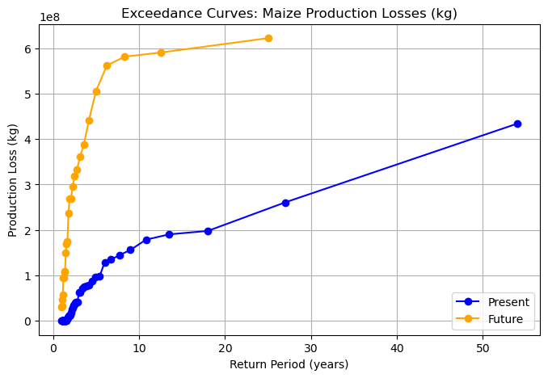

png

```python
import matplotlib.pyplot as plt

# ---------------------------
# Compare Exceedance curves
# ---------------------------

exceedance_present = impact_present.calc_freq_curve()
exceedance_future = impact_future.calc_freq_curve()

fig, axis = plt.subplots(figsize=(8, 5))
exceedance_present.plot(axis=axis, color="blue", marker="o", label="Present")
exceedance_future.plot(axis=axis, color="orange", marker="o", label="Future")
axis.set_title("Exceedance Curves: Maize Production Losses (kg)")
axis.set_xlabel("Return Period (years)")
axis.set_ylabel("Production Loss (kg)")
plt.grid(True)
axis.legend(loc="lower right")
plt.show()
plt.close(axis.figure)
```

This plot summarizes the dramatic changes from combined economic growth (effectively scaling along the y-axis) and climate change (as droughts intensify). The future exceedance curve is dramatically higher than the present-day exceedance.

[figure not shown]

png

[figure not shown]

png

```python
import contextily as ctx

# ----------------------------
# Map expected annual impacts
# ----------------------------

max_impact = impact_future.eai_exp.max()

axis = impact_present.plot_basemap_eai_exposure(
    ignore_zero=True,                   # Don't plot locations with zero impacts
    pop_name=False,                     # Don't plot place names
    buffer=50000,                         # Add spatial buffers to the map (in the CRS coordinate units)
    s=50,                                # The size of point markers on the plot
    zoom=8,                            # Level of detail to add to the basemap
    cmap="autumn_r",                    # Colour scheme to use for the points. See https://matplotlib.org/stable/tutorials/colors/colormaps.html for options.
    vmax=max_impact,                    # Set the maximum value for the colour scale
    url=ctx.providers.CartoDB.Positron, # Basemap provider
    figsize=(6, 8)
)
axis.set_title(f"Present-day Expected Annual Maize Production Losses (kg)")
plt.show()
plt.close(axis.figure)

axis = impact_future.plot_basemap_eai_exposure(
    ignore_zero=True,                   # Don't plot locations with zero impacts
    pop_name=False,                     # Don't plot place names
    buffer=50000,                         # Add spatial buffers to the map (in the CRS coordinate units)
    s=50,                                # The size of point markers on the plot
    zoom=8,                            # Level of detail to add to the basemap
    cmap="autumn_r",                    # Colour scheme to use for the points. See https://matplotlib.org/stable/tutorials/colors/colormaps.html for options.
    vmax=max_impact,                    # Set the maximum value for the colour scale
    url=ctx.providers.CartoDB.Positron, # Basemap provider
    figsize=(6, 8)
)
axis.set_title(f"Future Expected Annual Maize Production Losses (kg)")
plt.show()
plt.close(axis.figure)
```

### 8.4.1 Further exploration of the breakdown of risk

By running different Impact calculations, we can explore how changes to hazard and exposures drive changes in the risk calculation.

Here we show four risk calculations, each for different components of risk. (Some of these we did already but we show them again for completeness.). We can then summarize the results in a table and generate a more detailed waterfall plot.

```python
# 1. Present-day exposure + present-day hazard
impact_present_present = ImpactCalc(
    entity_present.exposures,
    entity_present.impact_funcs,
    haz_present
).impact(
    save_mat=True,
    assign_centroids=False,
    ignore_cover=True,
    ignore_deductible=True
)

# 2. Future exposure + present-day hazard
impact_future_exp_only = ImpactCalc(
    entity_future.exposures,
    entity_future.impact_funcs,
    haz_present
).impact(
    save_mat=True,
    assign_centroids=False,
    ignore_cover=True,
    ignore_deductible=True
)

# 3. Present-day exposure + future hazard
impact_future_haz_only = ImpactCalc(
    entity_present.exposures,
    entity_present.impact_funcs,
    haz_future
).impact(
    save_mat=True,
    assign_centroids=False,
    ignore_cover=True,
    ignore_deductible=True
)

# 4. Future exposure + future hazard
impact_future_combined = ImpactCalc(
    entity_future.exposures,
    entity_future.impact_funcs,
    haz_future
).impact(
    save_mat=True,
    assign_centroids=False,
    ignore_cover=True,
    ignore_deductible=True
)

decomp_df = pd.DataFrame({
    "Scenario": [
        "Present-day exposure + present-day hazard",
        "Future exposure + present-day hazard",
        "Present-day exposure + future hazard",
        "Future exposure + future hazard"
    ],
    "Average annual impact (kg)": [
        impact_present_present.aai_agg,
        impact_future_exp_only.aai_agg,
        impact_future_haz_only.aai_agg,
        impact_future_combined.aai_agg
    ]
})

decomp_df["% increase from baseline"] = (
    decomp_df["Average annual impact (kg)"]
    / decomp_df["Average annual impact (kg)"].iloc[0]
    - 1
) * 100

numeric_cols = decomp_df.select_dtypes(include="number").columns
display(
    decomp_df.style.format({
        "Average annual impact (kg)": "{:,.0f}",
        "% increase from baseline": "{:.2f}%"
    })
)
```

```
2026-07-03 18:45:19,059 - climada.engine.impact_calc - INFO - Calculating impact for 42 assets (>0) and 54 events.
2026-07-03 18:45:19,073 - climada.engine.impact_calc - INFO - Calculating impact for 42 assets (>0) and 54 events.
2026-07-03 18:45:19,079 - climada.engine.impact_calc - INFO - Calculating impact for 42 assets (>0) and 25 events.
2026-07-03 18:45:19,086 - climada.engine.impact_calc - INFO - Calculating impact for 42 assets (>0) and 25 events.
```

|  | Scenario | Average annual impact (kg) | % increase from baseline |
| --- | --- | --- | --- |
| 0 | Present-day exposure + present-day hazard | 53,198,268 | 0.00% |
| 1 | Future exposure + present-day hazard | 73,334,399 | 37.85% |
| 2 | Present-day exposure + future hazard | 198,381,234 | 272.91% |
| 3 | Future exposure + future hazard | 273,470,722 | 414.06% |

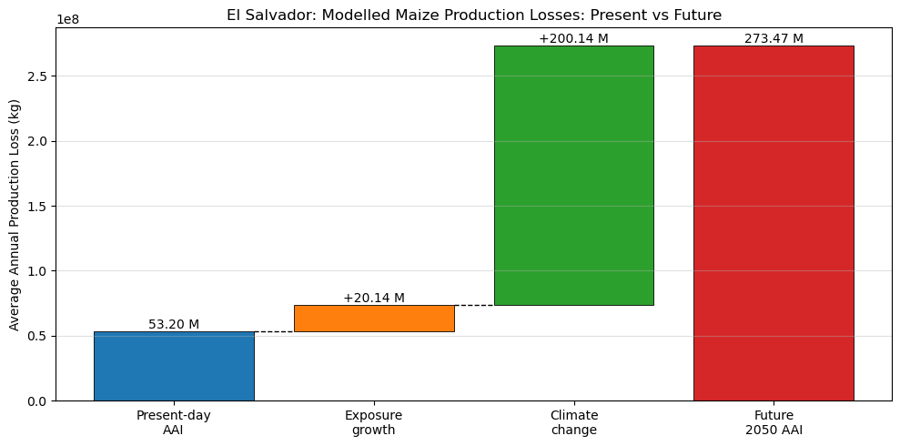

png

```python
# ---------------------------------------
# Create a more detailed waterfall plot
# ---------------------------------------

# Gather the data we need

baseline_aai = impact_present_present.aai_agg
exp_only_aai = impact_future_exp_only.aai_agg
combined_aai = impact_future_combined.aai_agg

exposure_growth_effect = exp_only_aai - baseline_aai
climate_change_effect = combined_aai - exp_only_aai

components = [
    "Present-day\nAAI",
    "Exposure\ngrowth",
    "Climate\nchange",
    "Future\n2050 AAI"
]

heights = [
    baseline_aai,
    exposure_growth_effect,
    climate_change_effect,
    combined_aai
]

bottoms = [
    0,
    baseline_aai,
    baseline_aai + exposure_growth_effect,
    0
]

colors = [
    "tab:blue",
    "tab:orange",
    "tab:green",
    "tab:red"
]

# Build the plot!

fig, ax = plt.subplots(figsize=(10, 5))

ax.bar(
    np.arange(len(components)),
    heights,
    bottom=bottoms,
    color=colors,
    edgecolor="black",
    linewidth=0.6
)

running_totals = [
    baseline_aai,
    baseline_aai + exposure_growth_effect,
    combined_aai
]

for i in range(len(running_totals) - 1):
    ax.plot(
        [i + 0.4, i + 1 - 0.4],
        [running_totals[i], running_totals[i]],
        color="black",
        linestyle="--",
        linewidth=1
    )

for i, (bottom, height) in enumerate(zip(bottoms, heights)):
    if i == 0 or i == len(components) - 1:
        label_y = height
        label_text = f"{height / 1e6:.2f} M"
    else:
        label_y = bottom + height
        label_text = f"+{height / 1e6:.2f} M"

    ax.text(
        i,
        label_y,
        label_text,
        ha="center",
        va="bottom",
        fontsize=10
    )

ax.set_xticks(np.arange(len(components)))
ax.set_xticklabels(components)
ax.set_ylabel("Average Annual Production Loss (kg)")
ax.set_title("El Salvador: Modelled Maize Production Losses: Present vs Future")
ax.grid(axis="y", alpha=0.4)

plt.tight_layout()
plt.show()

waterfall_plot_df = pd.DataFrame({
    "component": [
        "Present-day AAI",
        "Exposure growth",
        "Climate change",
        "Future 2050 AAI"
    ],
    "value_kg": heights,
    "bottom_kg": bottoms
})
```

### 8.4.2 Extensions to this notebook

Note: this is a first version of the notebook. It should give you enough information to build and run your own future risk analyses.

There are still a few improvements to make to the data: - use all three asset types - use projected socioeconomic change information to estimate future asset values - use longer future hazard time series - more scientifically-grounded estimations of the changes of drought risk – this seems very high!